[figure not shown]

# `pyam` an open-source Python package for IAM scenario analysis

[figure not shown]

## Daniel Huppmann, IIASA, huppmann@iiasa.ac.at

### The presentation is available at iiasa.github.io/ene-present.github.io/cdlinks-delhi2018

#### The `pyam` package is available at github.com/IAMconsortium/pyam

The package was developed by [Matthew Gidden](https://www.github.com/gidden) and [Daniel Huppmann](https://www.github.com/danielhuppmann).  
It is released under an [APACHE 2.0 Open-Source license](https://www.apache.org/licenses/LICENSE-2.0).

The presentation is based on a talk by Matthew Gidden given at [IAMC 2017, Recife, Brazil](http://mattgidden.com/presentations/pyam-iamc2017/) and the [tutorial notebooks](https://github.com/IAMconsortium/pyam/tree/master/tutorial) of the `pyam` package.

This presentation is licensed under  
a [Creative Commons Attribution 4.0 International License](http://creativecommons.org/licenses/by/4.0/).

[figure not shown]

# Diagnostics, analysis and visualization tools for Integrated Assessment timeseries data

## First steps with the `pyam` package

The `pyam` package provides a range of diagnostic tools and functions  
for analyzing and working with IAMC-style timeseries data.

The package can be used with data that follows the data template convention of the [Integrated Assessment Modeling Consortium](http://www.globalchange.umd.edu/iamc/) (IAMC). An illustrative example is shown below; see [data.ene.iiasa.ac.at/database](http://data.ene.iiasa.ac.at/database/) for more information.

| **model** | **scenario** | **region** | **variable** | **unit** | **2005** | **2010** | **2015** |
| --- | --- | --- | --- | --- | --- | --- | --- |
| MESSAGE V.4 | AMPERE3-Base | World | Primary Energy | EJ/y | 454.5 | 479.6 | ... |
| ... | ... | ... | ... | ... | ... | ... | ... |

## Features of the `pyam` package

### Validation, diagnostics and sanity checks of the data

### Visualization and plotting tools

### Categorization of scenarios and creation of metadata indicators

## Source of tutorial data

The timeseries data used in this tutorial is a partial snapshot of the scenario database compiled for the IPCC's Fifth Assessment Report (AR5):

> Krey V., O. Masera, G. Blanford, T. Bruckner, R. Cooke, K. Fisher-Vanden, H. Haberl, E. Hertwich, E. Kriegler, D. Mueller, S. Paltsev, L. Price, S. Schlömer, D. Ürge-Vorsatz, D. van Vuuren, and T. Zwickel, 2014: *Annex II: Metrics & Methodology*.  
> In: *Climate Change 2014: Mitigation of Climate Change. Contribution of Working Group III to the Fifth Assessment Report of the Intergovernmental Panel on Climate Change* [Edenhofer, O., R. Pichs-Madruga, Y. Sokona, E. Farahani, S. Kadner, K. Seyboth, A. Adler, I. Baum, S. Brunner, P. Eickemeier, B. Kriemann, J. Savolainen, S. Schlömer, C. von Stechow, T. Zwickel and J.C. Minx (eds.)]. Cambridge University Press, Cambridge, United Kingdom and New York, NY, USA. [Link](https://www.ipcc.ch/report/ar5/wg3/)

The complete AR5 scenario database is publicly available at tntcat.iiasa.ac.at/AR5DB/.

[figure not shown]

## Scientific references for selected tutorial data

The data snapshot used for this tutorial consists of selected data from two model intercomparison projects:

- Energy Modeling Forum Round 27 ([**EMF27**](https://emf.stanford.edu/projects/emf-27-global-model-comparison-exercise)), see the Special Issue in [*Climatic Change* 3-4, 2014](https://link.springer.com/journal/10584/123/3/page/1).
- EU FP7 project [**AMPERE**](https://tntcat.iiasa.ac.at/AMPEREDB/), see the following scientific publications:
  - Riahi, K., et al. (2015). "Locked into Copenhagen pledges — Implications of short-term emission targets for the cost and feasibility of long-term climate goals." *Technological Forecasting and Social Change* 90(Part A): 8-23.  
    [DOI: 10.1016/j.techfore.2013.09.016](https://doi.org/10.1016/j.techfore.2013.09.016)
  - Kriegler, E., et al. (2015). "Making or breaking climate targets: The AMPERE study on staged accession scenarios for climate policy." *Technological Forecasting and Social Change* 90(Part A): 24-44.  
    [DOI: 10.1016/j.techfore.2013.09.021](https://doi.org/10.1016/j.techfore.2013.09.021)

The data used in this tutorial is ONLY a partial snapshot  
of the IPCC AR5 scenario database!  
This tutorial is only intended for an illustration of the `pyam` package.

## Import package and load data from the AR5 tutorial csv snapshot file

First, we import the `pyam` package and load the timeseries data snapshot from the file `tutorial_AR5_data.csv` in the `pyam/tutorial` folder.

```python
%matplotlib inline
import pyam
```

```python
data = '../../pyam/tutorial/tutorial_AR5_data.csv'
df = pyam.IamDataFrame(data=data)
```

```
INFO:root:Reading `../../pyam/tutorial/tutorial_AR5_data.csv`
```

# What's in our dataset?

As a first step, we use a number of functions to find out what is included in the snapshot.

```python
df.models()
```

```
0    AIM-Enduse 12.1
1           GCAM 3.0
2          IMAGE 2.4
3        MERGE_EMF27
4        MESSAGE V.4
5         REMIND 1.5
6        WITCH_EMF27
Name: model, dtype: object
```

```python
df.scenarios()
```

```
0             AMPERE3-450
1         AMPERE3-450P-CE
2         AMPERE3-450P-EU
3             AMPERE3-550
4         AMPERE3-550P-EU
5     AMPERE3-Base-EUback
6       AMPERE3-CF450P-EU
7          AMPERE3-RefPol
8          EMF27-450-Conv
9         EMF27-450-NoCCS
10       EMF27-550-LimBio
11    EMF27-Base-FullTech
12          EMF27-G8-EERE
Name: scenario, dtype: object
```

```python
df.regions()
```

```
0      ASIA
1       LAM
2       MAF
3    OECD90
4       REF
5     World
Name: region, dtype: object
```

```python
df.variables(include_units=True)
```

|  | variable | unit |
| --- | --- | --- |
| 0 | Emissions\|CO2 | Mt CO2/yr |
| 1 | Emissions\|CO2\|Fossil Fuels and Industry | Mt CO2/yr |
| 2 | Emissions\|CO2\|Fossil Fuels and Industry\|Energy... | Mt CO2/yr |
| 3 | Emissions\|CO2\|Fossil Fuels and Industry\|Energy... | Mt CO2/yr |
| 4 | Price\|Carbon | US$2005/t CO2 |
| 5 | Primary Energy | EJ/yr |
| 6 | Primary Energy\|Coal | EJ/yr |
| 7 | Primary Energy\|Fossil\|w/ CCS | EJ/yr |
| 8 | Temperature\|Global Mean\|MAGICC6\|MED | °C |

## A first look at the data

We use the temperature outcome as the first variable of interest in our data snapshot.

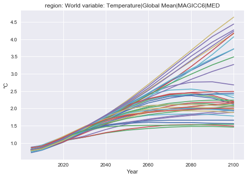

```python
v = 'Temperature|Global Mean|MAGICC6|MED'
df.filter({'region': 'World', 'variable': v}).line_plot(legend=False)
```

## Categorization of scenarios

We use the temperature outcome as a first criteria for categorization of scenarios.

The function `categorize()` assigns all scenarios fulfilling a number of criteria to a specific category. The function `metadata()` applies a categorization to all scenarios.

```python
df.metadata(meta='uncategorized', name='temperature')
```

```python
df.categorize(
    'temperature', 'Below 1.6C',
    criteria={v: {'up': 1.6, 'year': 2100}},
    color='cornflowerblue'
)
```

```
INFO:root:4 scenarios categorized as `temperature: Below 1.6C`
```

```python
df.categorize(
    'temperature', 'Below 2.0C',
    criteria={v: {'up': 2.0, 'lo': 1.6, 'year': 2100}},
    color='forestgreen'
)
```

```
INFO:root:8 scenarios categorized as `temperature: Below 2.0C`
```

```python
df.categorize(
    'temperature', 'Below 2.5C',
    criteria={v: {'up': 2.5, 'lo': 2.0, 'year': 2100}},
    color='gold'
)
```

```
INFO:root:16 scenarios categorized as `temperature: Below 2.5C`
```

```python
df.categorize(
    'temperature', 'Below 3.5C',
     criteria={v: {'up': 3.5, 'lo': 2.5, 'year': 2100}},
     color='firebrick'
)
```

```
INFO:root:3 scenarios categorized as `temperature: Below 3.5C`
```

```python
df.categorize(
    'temperature', 'Above 3.5C',
    criteria={v: {'lo': 3.5, 'year': 2100}},
    color='magenta'
)
```

```
INFO:root:9 scenarios categorized as `temperature: Above 3.5C`
```

### Checking for uncategorized scenarios

```python
df.filter({'temperature': 'uncategorized'})[['model', 'scenario']]\
    .drop_duplicates()
```

|  | model | scenario |
| --- | --- | --- |
| 0 | AIM-Enduse 12.1 | EMF27-450-Conv |
| 23 | AIM-Enduse 12.1 | EMF27-450-NoCCS |
| 46 | AIM-Enduse 12.1 | EMF27-550-LimBio |
| 69 | AIM-Enduse 12.1 | EMF27-Base-FullTech |
| 92 | AIM-Enduse 12.1 | EMF27-G8-EERE |
| 590 | WITCH_EMF27 | EMF27-450-Conv |
| 613 | WITCH_EMF27 | EMF27-550-LimBio |
| 636 | WITCH_EMF27 | EMF27-Base-FullTech |

The `pyam` package includes the function `require_variable()` to check a-priori whether a variable exists. The option `exclude: True` marks these scenarios as "exclude" in the metadata, so that they can be easily removed from further analysis.

```python
df.require_variable(variable=v, exclude=True)
```

```
INFO:root:8 scenarios do not include required variable `Temperature|Global Mean|MAGICC6|MED`, marked as `exclude: True` in metadata
```

|  | model | scenario |
| --- | --- | --- |
| 0 | AIM-Enduse 12.1 | EMF27-450-Conv |
| 1 | AIM-Enduse 12.1 | EMF27-450-NoCCS |
| 2 | AIM-Enduse 12.1 | EMF27-550-LimBio |
| 3 | AIM-Enduse 12.1 | EMF27-Base-FullTech |
| 4 | AIM-Enduse 12.1 | EMF27-G8-EERE |
| 5 | WITCH_EMF27 | EMF27-450-Conv |
| 6 | WITCH_EMF27 | EMF27-550-LimBio |
| 7 | WITCH_EMF27 | EMF27-Base-FullTech |

## Plotting the temperature outcome again using the categorization

We repeat the plot, this time excluding the uncategorized scenarios and using the `'temperature'` metadata column to assign colors. The colors of the individual categories were defined in the function `categorize()` above.

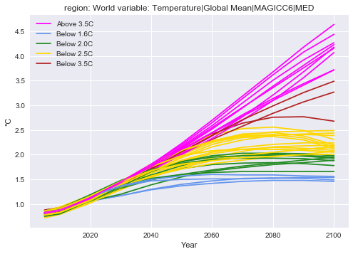

```python
df.filter({'variable': v, 'exclude': False})\
    .line_plot(color='temperature')
```

### Using the categorization to analyse other variables

We now plot the timeseries data of the 'Primary Energy' variable, using the color-coding of the Temperature categorization to analyse the correlation between energy consumption and warming.

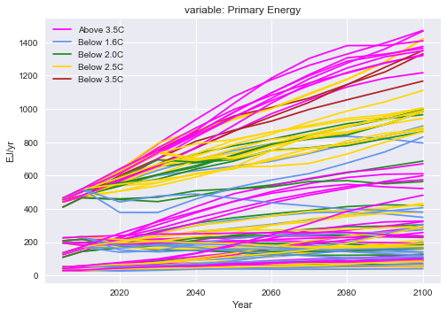

```python
df.filter({'variable': 'Primary Energy', 'exclude': False})\
    .line_plot(color='temperature')
```

## Filtering scenarios by Primary Energy in the base year

To get clearer understanding of the relationship between Primary Energy and Warming, we focus on only those scenarios that have similar levels of Primary Energy in the base year (2010).

We first use the function `validate()` to check that certain values are within a given range,

```python
df.validate(criteria={'Primary Energy': {'lo': 400, 'year': 2010}}).head()
```

```
INFO:root:104 of 6622 data points to not satisfy the criteria
```

|  | model | scenario | region | variable | unit | year | value |
| --- | --- | --- | --- | --- | --- | --- | --- |
| 672 | AIM-Enduse 12.1 | EMF27-450-Conv | REF | Primary Energy | EJ/yr | 2010 | 52.61 |
| 666 | AIM-Enduse 12.1 | EMF27-450-Conv | MAF | Primary Energy | EJ/yr | 2010 | 50.12 |
| 660 | AIM-Enduse 12.1 | EMF27-450-Conv | ASIA | Primary Energy | EJ/yr | 2010 | 168.75 |
| 669 | AIM-Enduse 12.1 | EMF27-450-Conv | OECD90 | Primary Energy | EJ/yr | 2010 | 202.29 |
| 663 | AIM-Enduse 12.1 | EMF27-450-Conv | LAM | Primary Energy | EJ/yr | 2010 | 31.42 |

## Assigning valid scenarios to a new category

We assign those scenarios that have a Primary Energy level above 400 EJ/y in 2010 to a new category, and then re-display the previous figure including only these scenarios.

```python
df.metadata(meta='uncategorized', name='PE')
```

```python
df.categorize(name='PE', value='high',
              criteria={'Primary Energy': {'lo': 400, 'year': 2010}})
```

```
INFO:root:24 scenarios categorized as `PE: high`
```

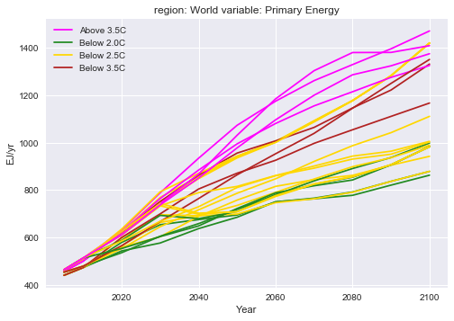

```python
df.filter(
    {'variable': 'Primary Energy', 'exclude': False, 'PE': 'high'})\
    .line_plot(color='temperature')
```

## Highlighting particular models and scenarios

Next, we want to check how one particular model behaves within an ensemble of scenarios.

```python
df.metadata(meta='uncategorized', name='model_family')
```

```python
pyam.categorize(
    df, filters={'model': 'MESSAGE*'}, name='model_family', value='MESSAGE',
    criteria={'Primary Energy': {'lo': 400, 'year': 2010}},
    marker='o')
```

```
INFO:root:4 scenarios categorized as `model_family: MESSAGE`
```

```python
from pyam.plotting import run_control
rc = run_control()
rc.update({'marker': {'model_family': {'uncategorized': None}}})
```

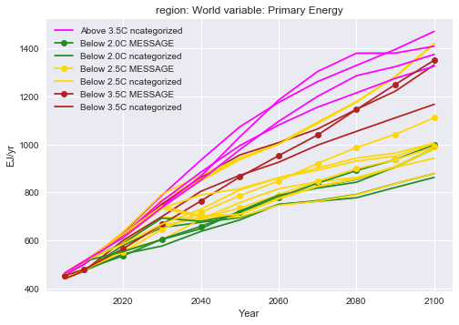

```python
df.filter(
    {'variable': 'Primary Energy', 'exclude': False, 'PE': 'high'})\
    .line_plot(color='temperature', marker='model_family')
```

### And just for the fun of it, let's add scenario linestyles, too...

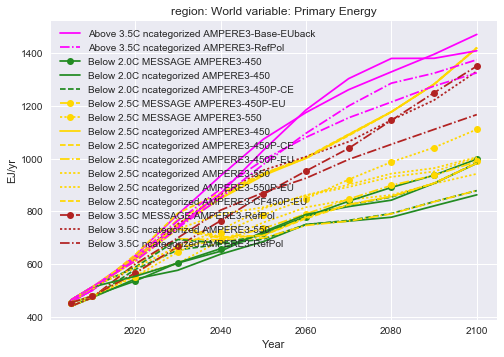

```python
df.filter(
    {'variable': 'Primary Energy', 'exclude': False, 'PE': 'high'})\
    .line_plot(color='temperature', marker='model_family',
               linestyle='scenario', legend=True)
```

## Further analysis using metadata

Rather than plotting the development over time, it is often useful to extract and visualize key indicators. In this example, we determine the year of peak warming and plot this indicator against the cumulative CO2 emissions from 2010 until that year.

```python
def peak_warming(x, peak_year=False):
    peak = x[x == x.max()]
    if peak_year:
        return peak.index[0]
    else:
        return float(max(peak))
```

```python
mean_temperature = df.filter(filters={'variable': v}).timeseries()
```

```python
df.metadata(
    mean_temperature.apply(peak_warming, raw=False, axis=1),
    'median warming at peak')
```

```python
df.metadata(
    mean_temperature.apply(peak_warming, peak_year=True, raw=False, axis=1),
    'year of peak warming')
```

```python
co2 = df.filter({'region': 'World', 'variable': 'Emissions|CO2'})\
    .timeseries() / 1000
```

```python
df.metadata(
    co2.apply(lambda x:
              pyam.cumulative(x, first_year=2010,
                              last_year=df.meta.loc[x.name[0:2],
                                                    'year of peak warming']),
              raw=False, axis=1),
    'cumulative CO2 emissions (2010 to peak warming)')
```

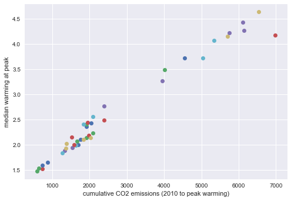

```python
df.filter({'exclude': False}).\
    scatter(x='cumulative CO2 emissions (2010 to peak warming)',
            y='median warming at peak')
```

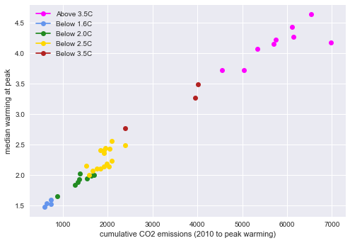

```python
df.filter({'exclude': False}).\
    scatter(x='cumulative CO2 emissions (2010 to peak warming)',
            y='median warming at peak',
            color='temperature')
```

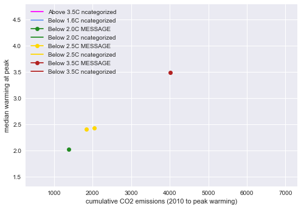

```python
df.filter({'exclude': False}).\
    scatter(x='cumulative CO2 emissions (2010 to peak warming)',
            y='median warming at peak',
            color='temperature', marker='model_family')
```

We had previously defined the marker for the scenarios not categorized by model family as `None`, so no marker is shown in the previous scatterplot.

We can easily reset that marker as illustrated below.

```python
rc.update({'marker': {'model_family': {'uncategorized': '*'}}})
```

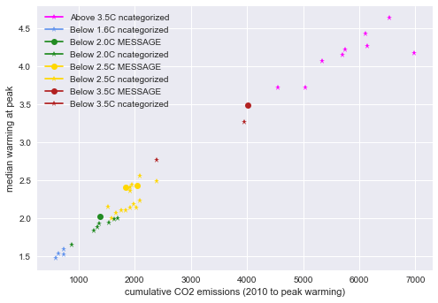

```python
df.filter({'exclude': False}).\
    scatter(x='cumulative CO2 emissions (2010 to peak warming)',
            y='median warming at peak',
            color='temperature', marker='model_family')
```

## Looking at regional disaggregation for a particular scenario

```python
df_ = df.filter({'model': 'MESSAGE*', 'scenario': 'EMF27-550-LimBio',
                 'variable': 'Emissions|CO2'})
```

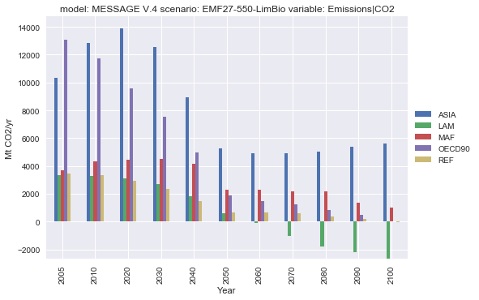

```python
df_.filter({'region': 'World'}, keep=False).bar_plot(bars='region')
```

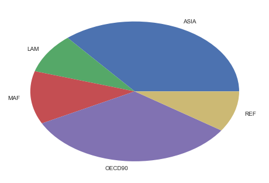

```python
df_.filter({'region': 'World'}, keep=False).\
    filter({'year': 2010}).pie_plot(category='region')
```

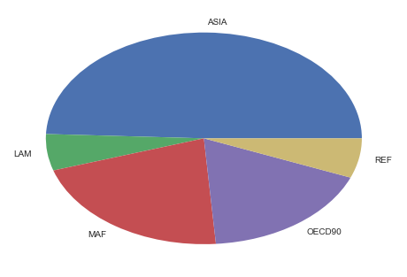

```python
df_.filter({'region': 'World'}, keep=False).\
    filter({'year': 2050}).pie_plot(category='region')
```

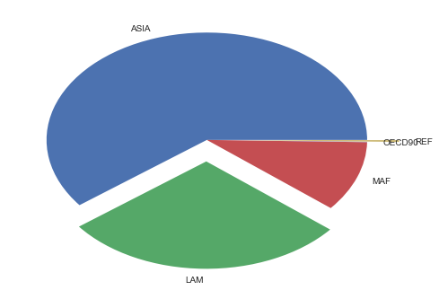

```python
df_.filter({'region': 'World'}, keep=False)\
    .filter({'year': 2100}).pie_plot(category='region')
```

## And finally - who doesn't like maps?

This feature is work in progress. The following figure is based on the unit test and the CEDS Harmonization work by Matt Gidden.

```
<cartopy.mpl.geoaxes.GeoAxesSubplot at 0x1143bca58>
```

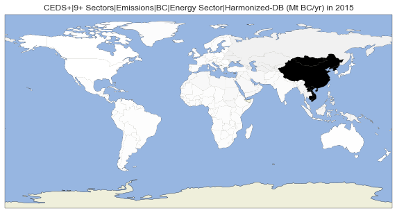

```python
import matplotlib.pyplot as plt
import cartopy
fig, ax = plt.subplots(
    subplot_kw={'projection': cartopy.crs.PlateCarree()}, figsize=(10, 7))
df.map_regions('iso').region_plot(ax=ax, cbar=False)
```

[figure not shown]

## Summary, conclusions, outlook

### The `pyam` package ...

#### 1. is a toolbox for AUTOMATED sanity checks and diagnostics of scenarios

#### 2. allows efficient analysis of scenarios in model comparison exercises

#### 3. provides a number of 'out-of-the-box' visualization tools

### We hope that the package will develop into a valuable resource for the energy modeling and integrated assessment community!

### Please send suggestions or contribute to the package development on GitHub!

### Find out more on github.com/IAMconsortium/pyam